# Лабораторная работа №8

Познакомиться с операционной системой Linux. Получить практические навыки работы с редактором vi, установленным по умолчанию практически во всех дистрибутивах.

Ким Э.А

Российский университет дружбы народов, Москва, Россия

# Информация

## Докладчик

- Ким Эрика Алексеевна
- НБИ-02-22
- РУДН

## Цели и задачи

- Познакомиться с операционной системой Linux. Получить практические навыки работы с редактором vi, установленным по умолчанию практически во всех дистрибутивах.

## Этапы работы

1. Создайте каталог с именем ~/work/os/lab08.Перейдите во вновь созданный каталог.Вызовите vi и создайте файл hello.sh

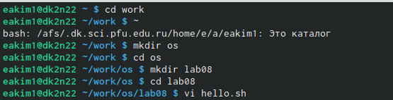

…

2. Нажмите клавишу i и вводите следующий текст.

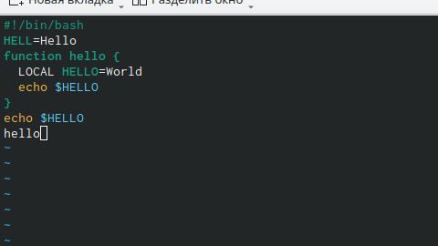

…

3. Нажмите клавишу Esc для перехода в командный режим после завершения ввода текста.Нажмите : для перехода в режим последней строки и внизу вашего экрана появится приглашение в виде двоеточия.Нажмите w (записать) и q (выйти), а затем нажмите клавишу Enter для сохранения вашего текста и завершения работы..

…

4. Сделайте файл исполняемым

…

5. Перейдите в режим вставки и замените на HELLO. Нажмите Esc для возврата в командный режим.

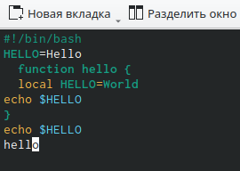

…

6. Установите курсор на последней строке файла. Вставьте после неё строку, содержащую следующий текст: echo $HELLO

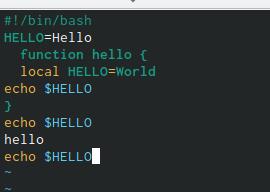

…

7. Нажмите Esc для перехода в командный режим.Удалите последнюю строку.

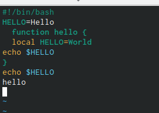

…

8. Введите команду отмены изменений u для отмены последней команды. Введите символ : для перехода в режим последней строки. Запишите произведённые изменения и выйдите из vi

…

## Вывод

- мы молодцы